# Analysis, Visualization and Mapping in R

## Aula 4 Objetivos

- Saber como a realizar regressões em nosso 'pipeline' de trabalho
- Incentivar o uso de 'predicted values' ao lado de coefficients e p-values

## Revisão de Regressões

Regressão é apenas a análise de variação nos dados

Três elementos fundamentais:

1. A lógica de inferência causal informa **quais variáveis incluímos**
2. O tipo/escala da outcome variável informa **qual modelo (função de link) usamos**
3. O tipo/escala do tratamento e do resultado determinam **como interpretamos os resultados**

## Fórmula de Regressão

- `Y ~ X`
- `Y ~ X1 + X2`
- `Y ~ X1*X2`

## Modelos de Regressão

- Continuous -> Ordinary Least Squares  
  `d %>% zelig(Y ~ X,data=.,model="ls")`
- Binary -> Logit  
  `d %>% zelig(Y ~ X,data=.,model="logit")`
- Unordered categories -> Multinomial logit  
  `d %>% zelig(Y ~ X,data=.,model="mlogit")`
- Ordered categories -> Ordered logit  
  `d %>% zelig(Y ~ X,data=.,model="ologit")`
- Count -> Poisson  
  `d %>% zelig(Y ~ X,data=.,model="poisson")`

## Interpretação de Regressão

- Difícil! Depende da escala da variável de tratamento, da escala do resultado, do modelo utilizado e da presença de quaisquer interações, etc.
- Para o OLS básico: 1 [unidade de tratamento] mudança no tratamento está associada com uma mudança de \(\beta\) [unidades de resultado] no resultado
- Freqüentemente, é melhor focar nos 'predicted values': Da nossa equação de regressão (com nossos coeficientes estimados), quais valores de \(Y\) esperamos para valores específicos de \(X\)?
  - Ideal para visualização

## Usando Zelig

- Controlando para os horários de partida programados, os diferentes aeroportos têm atrasos médios de partida diferentes?

```r
flights %>% zelig(dep_delay ~ origin + dep_time, data=., model="ls")
```

```
## Model:
##
## Call:
## z5$zelig(formula = formula, data = data, by = by)
##
## Residuals:
##     Min      1Q  Median      3Q     Max
##  -68.91  -18.61   -8.10    1.36 1305.19
##
## Coefficients:
##               Estimate Std. Error t value Pr(>|t|)
## (Intercept) -1.365e+01  2.174e-01  -62.81   <2e-16
## originJFK   -4.327e+00  1.631e-01  -26.53   <2e-16
## originLGA   -4.190e+00  1.661e-01  -25.22   <2e-16
## dep_time     2.152e-02  1.389e-04  154.89   <2e-16
##
## Residual standard error: 38.77 on 328517 degrees of freedom
##   (8255 observations deleted due to missingness)
## Multiple R-squared:  0.0703, Adjusted R-squared:  0.07029
## F-statistic:  8281 on 3 and 328517 DF,  p-value: < 2.2e-16
##
## Next step: Use 'setx' method
```

## Tabelas de Regressão

- Controlando para os horários de partida programados, os diferentes aeroportos têm atrasos médios de partida diferentes?
- Use `stargazer()`
- Lembre-se de definir os parâmetros do chunk como`` `r, results='asis'` ``

```r
flights %>% zelig(dep_delay ~ origin + dep_time, data=., model="ls") %>%
  from_zelig_model() %>%
  stargazer()
```

|  | *Dependent variable:* |
| --- | --- |
|  | dep_delay |
| originJFK | -4.327*** |
|  | (0.163) |
| originLGA | -4.190*** |
|  | (0.166) |
| dep_time | 0.022*** |
|  | (0.0001) |
| Constant | -13.655*** |
|  | (0.217) |
| Observations | 328,521 |
| R<sup>2</sup> | 0.070 |
| Adjusted R<sup>2</sup> | 0.070 |
| Residual Std. Error | 38.771 (df = 328517) |
| F Statistic | 8,280.601*** (df = 3; 328517) |
| *Note:* | p<0.1; p<0.05; p<0.01 |

## Tabelas de Regressão

- Controlando para os horários de partida programados, os diferentes aeroportos têm atrasos médios de partida diferentes?
- Use `stargazer()`
- Lembre-se de definir os parâmetros do chunk como`` `r, results='asis'` ``

```r
flights %>% zelig(dep_delay ~ origin + dep_time, data=., model="ls") %>%
  from_zelig_model() %>%
  stargazer(title="Regression Results",style="apsr",dep.var.labels=c("Departure Delay"), digits=1)
```

**Regression Results**

|  | Departure Delay |
| --- | --- |
| originJFK | -4.3*** |
|  | (0.2) |
| originLGA | -4.2*** |
|  | (0.2) |
| dep_time | 0.02*** |
|  | (0.000) |
| Constant | -13.7*** |
|  | (0.2) |
| N | 328,521 |
| R<sup>2</sup> | 0.1 |
| Adjusted R<sup>2</sup> | 0.1 |
| Residual Std. Error | 38.8 (df = 328517) |
| F Statistic | 8,280.6*** (df = 3; 328517) |
| p < .1; p < .05; p < .01 |  |

## Modelo Logit

- Controlando para os horários de partida programados, os diferentes aeroportos têm mais ou menos voos partindo na hora?

```r
flights %>% mutate(Late=ifelse(dep_delay>0,1,0)) %>%
  zelig(Late ~ origin + dep_time, data=., model="logit") %>%
  from_zelig_model() %>%
  stargazer()
```

|  | *Dependent variable:* |
| --- | --- |
|  | Late |
| originJFK | -0.372*** |
|  | (0.009) |
| originLGA | -0.496*** |
|  | (0.009) |
| dep_time | 0.001*** |
|  | (0.00001) |
| Constant | -1.913*** |
|  | (0.013) |
| Observations | 328,521 |
| Log Likelihood | -204,876.000 |
| Akaike Inf. Crit. | 409,759.900 |
| *Note:* | p<0.1; p<0.05; p<0.01 |

## Standard Errors

- Zelig usa automaticamente bootstrapping para calcular standard errors
- Então eles provavelmente já são SEs "robustos"
- Infelizmente, não existe uma maneira de especificar SEs em cluster no momento

## Predicted values

- Por exemplo, qual é o atraso médio para um voo das 18h de Newark?
- Note que quaisquer variáveis que não sejam 'setx' serão definidas para a ** mediana **

```r
flights %>% mutate(origin=as.factor(origin)) %>%
  zelig(dep_delay ~ origin + dep_time, data=., model="ls") %>%
  setx(origin="EWR", dep_time=1800) %>%
  sim()
```

```
##
##  sim x :
##  -----
## ev
##       mean        sd      50%     2.5%    97.5%
## 1 25.07474 0.1271728 25.07832 24.82485 25.32464
## pv
##          mean       sd      50%      2.5%    97.5%
## [1,] 25.73726 37.79083 25.56112 -46.07202 103.2223
```

## Predicted values

- Por exemplo, qual é o atraso médio para um voo das 18h de Newark?
- Note que quaisquer variáveis que não sejam 'setx' serão definidas para a ** mediana **

```r
flights %>% mutate(origin=as.factor(origin)) %>%
  zelig(dep_delay ~ origin + dep_time, data=., model="ls") %>%
  setx(origin="EWR", dep_time=1800) %>%
  sim() %>%
  zelig_qi_to_df()
```

| setx_value | dep_time | origin | expected_value | predicted_value |
| --- | --- | --- | --- | --- |
| x | 1800 | EWR | 25.28904 | 55.9979921 |
| x | 1800 | EWR | 25.17755 | -0.9117075 |
| x | 1800 | EWR | 25.17576 | 53.3361651 |
| x | 1800 | EWR | 24.89808 | 18.3176746 |
| x | 1800 | EWR | 25.23642 | -33.8479724 |
| x | 1800 | EWR | 25.19635 | 64.8123159 |
| x | 1800 | EWR | 25.19396 | 7.0235926 |
| x | 1800 | EWR | 25.27680 | -22.0220030 |
| x | 1800 | EWR | 24.91373 | 23.1823323 |
| x | 1800 | EWR | 25.18631 | 30.6466137 |
| x | 1800 | EWR | 25.03615 | 18.8046293 |
| x | 1800 | EWR | 25.11585 | 20.3787762 |
| x | 1800 | EWR | 24.81270 | 22.9971457 |
| x | 1800 | EWR | 25.09939 | -22.0420811 |
| x | 1800 | EWR | 25.05616 | 142.7537812 |
| x | 1800 | EWR | 24.96144 | 24.7822638 |
| x | 1800 | EWR | 25.12148 | 52.1525978 |
| x | 1800 | EWR | 25.09324 | 63.8321423 |
| x | 1800 | EWR | 25.24462 | 35.4440097 |
| x | 1800 | EWR | 25.27756 | 18.2218304 |
| x | 1800 | EWR | 25.35682 | 51.6869510 |
| x | 1800 | EWR | 25.03738 | 34.9847053 |
| x | 1800 | EWR | 24.93520 | 33.7702423 |
| x | 1800 | EWR | 25.07127 | 0.5750688 |
| x | 1800 | EWR | 25.12708 | 104.6712426 |
| x | 1800 | EWR | 25.06353 | 59.8845122 |
| x | 1800 | EWR | 25.15173 | 27.7811278 |
| x | 1800 | EWR | 25.18725 | -10.0150814 |
| x | 1800 | EWR | 25.18298 | 39.0902563 |
| x | 1800 | EWR | 25.09045 | -13.4855987 |

[output cut: 970 more lines]

## Predicted values

- Por exemplo, qual é o atraso médio para um voo das 18h de Newark?
- Note que quaisquer variáveis que não sejam 'setx' serão definidas para a ** mediana **

```r
flights %>% mutate(origin=as.factor(origin)) %>%
  zelig(dep_delay ~ origin + dep_time, data=., model="ls") %>%
  setx(origin="EWR", dep_time=1800) %>%
  sim() %>%
  zelig_qi_to_df() %>%
  summarise(avg_delay=mean(predicted_value))
```

| avg_delay |
| --- |
| 25.33659 |

## Predicted values

- Por exemplo, qual é o atraso médio para um voo das 18h de Newark?
- Note que quaisquer variáveis que não sejam 'setx' serão definidas para a ** mediana **

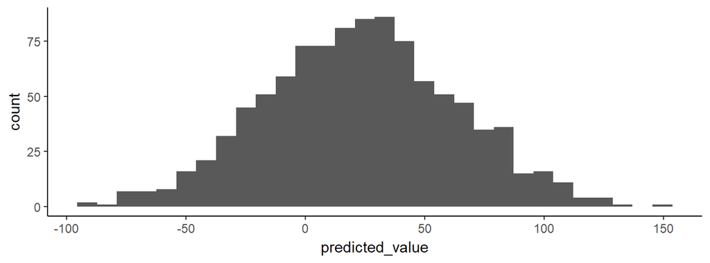

```r
flights %>% mutate(origin=as.factor(origin)) %>%
  zelig(dep_delay ~ origin + dep_time, data=., model="ls") %>%
  setx(origin="EWR", dep_time=1800) %>%
  sim() %>%
  zelig_qi_to_df() %>%
  ggplot() +
  geom_histogram(aes(x=predicted_value))
```

## Predicted values

- **Qual a probabilidade** de que um voo das 18h de Newark seja atrasado?

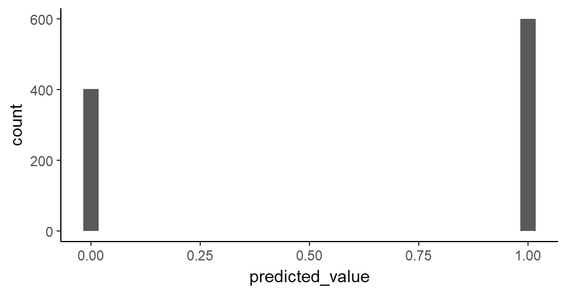

```r
flights %>% mutate(origin=as.factor(origin)) %>%
  mutate(Late=ifelse(dep_delay>0,1,0)) %>%
  zelig(Late ~ origin + dep_time, data=., model="logit") %>%
  setx(origin="EWR", dep_time=1800) %>%
  sim() %>%
  zelig_qi_to_df() %>%
  ggplot() +
  geom_histogram(aes(x=predicted_value))
```

- E se quisermos analisar um efeito de tratamento?
- Se um voo de Newark for reprogramado das 18h às 14h, qual será a redução no atraso?

```r
flights %>% mutate(origin=as.factor(origin)) %>%
  mutate(Late=ifelse(dep_delay>0,1,0)) %>%
  zelig(dep_delay ~ origin + dep_time, data=., model="logit") %>%
  setx(origin="EWR", dep_time=1800) %>%
  setx1(origin="EWR", dep_time=1400) %>%
  sim() %>%
  zelig_qi_to_df() %>%
  group_by(dep_time) %>%
  summarize(avg_Late=mean(predicted_value))
```

[output not shown]

- E se quisermos analisar um efeito de tratamento?
- Se um voo de Newark for reprogramado das 18h às 14h, qual será a redução no atraso?

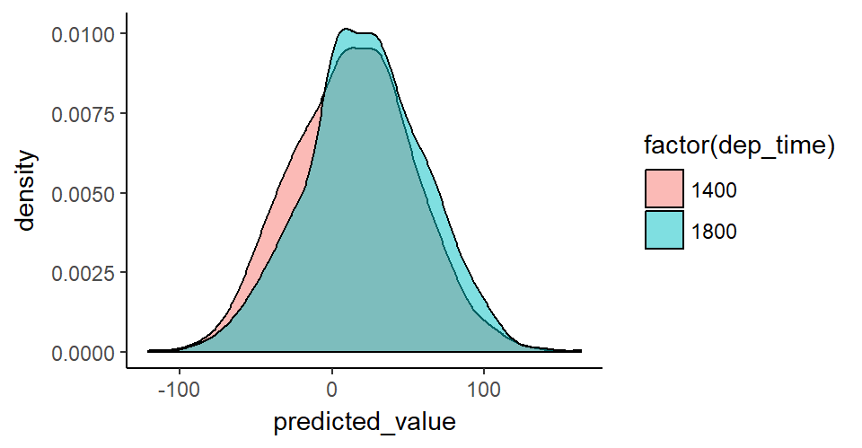

```r
flights %>% mutate(origin=as.factor(origin)) %>%
  zelig(dep_delay ~ origin + dep_time, data=., model="ls") %>%
  setx(origin="EWR", dep_time=1800) %>%
  setx1(origin="EWR", dep_time=1400) %>%
  sim() %>%
  zelig_qi_to_df() %>%
  ggplot() +
  geom_density(aes(x=predicted_value,group=factor(dep_time),fill=factor(dep_time)),alpha=0.5)
```